# Source memory performance for objects inside the rooms

# 1 Visual inspection of the data

# 2 Novelty Benefits

## 2.1 Compare mean accuracy between *novel* and *familiar* rooms

## 2.2 Check the data

**Is there any corrected hit rate < 0?**

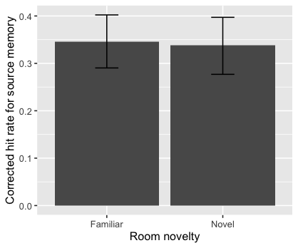

| Group | Mean | SD | N |
| --- | --- | --- | --- |
| Novel | 0.3379421 | 0.1926383 | 40 |
| Familiar | 0.3453563 | 0.1714696 | 40 |

```
    Paired t-test

data:  SrcAcc by Group
t = 0.28767, df = 39, p-value = 0.7751
alternative hypothesis: true difference in means is not equal to 0
95 percent confidence interval:
 -0.04471804  0.05954647
sample estimates:
mean of the differences
            0.007414216
```

## 2.3 Any difference between *Early* and *Later* object groups?

**Is there any corrected hit rate < 0?**

| SubjectNo | Group | ObjOrdGrp | MeanCurRt | MeanDur | SFHit | SHit | SrcHit | SFFalse | SFalse | SrcFalse | SFAcc | SAcc | SrcAcc |
| --- | --- | --- | --- | --- | --- | --- | --- | --- | --- | --- | --- | --- | --- |
| P03 | Novel | Later | 5.666667 | NaN | 0.7777778 | 0.7777778 | 0 | 0.15000000 | 0.05000000 | 0.05000000 | 0.6277778 | 0.72777778 | -0.05000000 |
| P03 | Familiar | Later | 3.571429 | NaN | 0.7142857 | 0.7142857 | 0 | 0.15000000 | 0.05000000 | 0.05000000 | 0.5642857 | 0.66428571 | -0.05000000 |
| P63 | Novel | Early | 6.000000 | 120.46042 | 1.0000000 | 0.8888889 | 0 | 0.05555556 | 0.00000000 | 0.01851852 | 0.9444444 | 0.88888889 | -0.01851852 |
| P73 | Familiar | Later | 6.333333 | 98.06488 | 0.6666667 | 0.3333333 | 0 | 0.16666667 | 0.00000000 | 0.01851852 | 0.5000000 | 0.33333333 | -0.01851852 |
| P76 | Novel | Later | 2.333333 | 103.24990 | 0.7777778 | 0.6666667 | 0 | 0.27777778 | 0.11111111 | 0.09259259 | 0.5000000 | 0.55555556 | -0.09259259 |
| P82 | Novel | Early | 5.333333 | 119.54276 | 0.8888889 | 0.4444444 | 0 | 0.50000000 | 0.05555556 | 0.14814815 | 0.3888889 | 0.38888889 | -0.14814815 |
| P86 | Novel | Later | 6.333333 | 96.12738 | 0.3333333 | 0.2222222 | 0 | 0.44444444 | 0.16666667 | 0.11111111 | -0.1111111 | 0.05555556 | -0.11111111 |

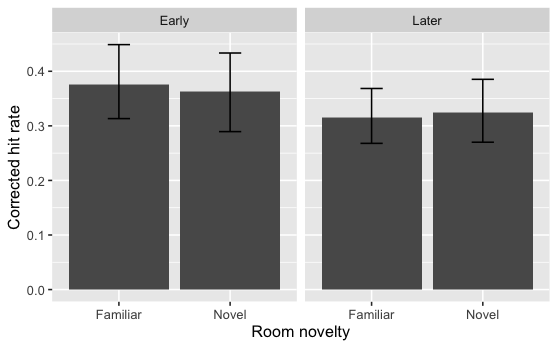

| Group | ObjOrdGrp | Mean | SD | N |
| --- | --- | --- | --- | --- |
| Novel | Early | 0.3624111 | 0.2281506 | 40 |
| Novel | Later | 0.3243092 | 0.1789658 | 40 |
| Familiar | Later | 0.3151657 | 0.1737029 | 40 |
| Familiar | Early | 0.3763000 | 0.2237931 | 40 |

|  | Effect | DFn | DFd | F | p | p<.05 | ges |
| --- | --- | --- | --- | --- | --- | --- | --- |
| 2 | Group | 1 | 39 | 0.008928582 | 0.92520281 |  | 3.513368e-05 |
| 3 | ObjOrdGrp | 1 | 39 | 5.383802838 | 0.02564695 | * | 1.513268e-02 |
| 4 | Group:ObjOrdGrp | 1 | 39 | 0.267372405 | 0.60802017 |  | 8.270238e-04 |

```
NA
```

# 3 Curiosity Enhancement

## 3.1 Check the data

### 3.1.1 Is there any corrected hit rate < 0?

#### 3.1.1.1 For the data per room

- There are 10 negative values out of a total of 239 values.

#### 3.1.1.2 For the data per curiosity group

- There are 10 negative value for curiosity group (1 ~ 3 and 5 ~ 7) out of a total of 78 values.

#### 3.1.1.3 For the data per curiosity group (median)

- There are 10 negative value for curiosity group (median) out of a total of 79 values.

## 3.2 Mean accuracy of item memory as a function of curiosity rating

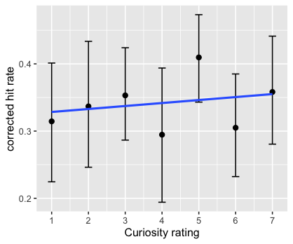

## 3.3 Testing the relationship between mean accuracy of item memory and curiosity rating

Build models with item memory accuracy as $y$ and examine effects of curiosity rating by including it into the model and then comparing the model fits.

- `baseline.rating` is the model with only an intercept, showing no change in item memory as a function of curiosity rating.
- `rating.intercept` is the model with $\small CuriosityRating$ included, showing the effects of curiosity rating.
- `rating.slope` is the model allowing the slope (i.e., relationship between item memory and curiosity rating) varying across participants.

|  | Model | df | AIC | BIC | logLik | Test | L.Ratio | p-value |
| --- | --- | --- | --- | --- | --- | --- | --- | --- |
| baseline.rating | 1 | 3 | -21.40250 | -10.973107 | 13.70125 |  |  |  |
| rating.intercept | 2 | 4 | -19.78401 | -5.878157 | 13.89200 | 1 vs 2 | 0.3815137 | 0.5368 |
| rating.slope | 3 | 6 | -15.77951 | 5.079273 | 13.88975 | 2 vs 3 | 0.0045027 | 0.9978 |

## 3.4 Check the curiosity groups

### 3.4.1 Separate the groups according to the rating

- *High*: curiosity rating > 4
- *Low*: curiosity rating < 4
- For curiosity rating = 4, discarded

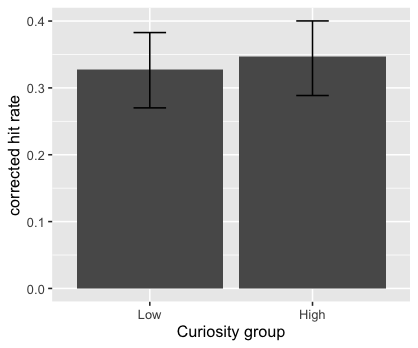

| CurGrp | Mean | SD | N |
| --- | --- | --- | --- |
| High | 0.3465083 | 0.1935414 | 40 |
| Low | 0.3280297 | 0.1763392 | 38 |

```
Linear mixed-effects model fit by maximum likelihood
 Data: inside.hit.rate.curiosity.group
```

|  | AIC | BIC | logLik |
| --- | --- | --- | --- |
|  | -54.69636 | -40.55611 | 33.34818 |

```
Random effects:
 Formula: ~1 + CurGrp | SubjectNo
 Structure: General positive-definite, Log-Cholesky parametrization
            StdDev     Corr
(Intercept) 0.16066635 (Intr)
CurGrpHigh  0.11970674 -0.199
Residual    0.06362605

Fixed effects: SrcAcc ~ CurGrp
```

|  | Value | Std.Error | DF | t-value | p-value |
| --- | --- | --- | --- | --- | --- |
| (Intercept) | 0.3267326 | 0.02808308 | 39 | 11.634502 | 0.0000 |
| CurGrpHigh | 0.0197757 | 0.02445148 | 37 | 0.808773 | 0.4238 |

```
 Correlation:
           (Intr)
CurGrpHigh -0.327

Standardized Within-Group Residuals:
        Min          Q1         Med          Q3         Max
-1.23346048 -0.26661159 -0.03746974  0.33341203  0.92489285

Number of Observations: 78
Number of Groups: 40
```

#### 3.4.1.1 Curiosity groups and temporal order of the objects

##### 3.4.1.1.1 Check the data

| SubjectNo | CurGrp | ObjOrdGrp | SFHit | SHit | SrcHit | SFFalse | SFalse | SrcFalse | SFAcc | SAcc | SrcAcc |
| --- | --- | --- | --- | --- | --- | --- | --- | --- | --- | --- | --- |
| P02 | High | Early | 0.6666667 | 0.6666667 | 0 | 0.31578947 | 0.00000000 | 0.01754386 | 0.35087719 | 0.66666667 | -0.01754386 |
| P02 | Low | Later | 1.0000000 | 1.0000000 | 0 | 0.31578947 | 0.00000000 | 0.01754386 | 0.68421053 | 1.00000000 | -0.01754386 |
| P03 | High | Later | 0.6666667 | 0.6666667 | 0 | 0.15000000 | 0.05000000 | 0.05000000 | 0.51666667 | 0.61666667 | -0.05000000 |
| P03 | Low | Later | 1.0000000 | 1.0000000 | 0 | 0.15000000 | 0.05000000 | 0.05000000 | 0.85000000 | 0.95000000 | -0.05000000 |
| P04 | High | Early | 0.8333333 | 0.8333333 | 0 | 0.31578947 | 0.26315789 | 0.03508772 | 0.51754386 | 0.57017544 | -0.03508772 |
| P63 | High | Early | 1.0000000 | 0.8888889 | 0 | 0.05555556 | 0.00000000 | 0.01851852 | 0.94444444 | 0.88888889 | -0.01851852 |
| P73 | High | Later | 0.6666667 | 0.3333333 | 0 | 0.16666667 | 0.00000000 | 0.01851852 | 0.50000000 | 0.33333333 | -0.01851852 |
| P76 | Low | Later | 0.6666667 | 0.5000000 | 0 | 0.27777778 | 0.11111111 | 0.09259259 | 0.38888889 | 0.38888889 | -0.09259259 |
| P82 | High | Early | 0.8333333 | 0.1666667 | 0 | 0.50000000 | 0.05555556 | 0.14814815 | 0.33333333 | 0.11111111 | -0.14814815 |
| P86 | High | Later | 0.3333333 | 0.2222222 | 0 | 0.44444444 | 0.16666667 | 0.11111111 | -0.11111111 | 0.05555556 | -0.11111111 |

[output cut: 1 more lines]

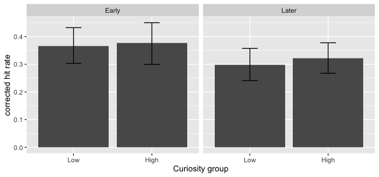

| CurGrp | ObjOrdGrp | Mean | SD | N |
| --- | --- | --- | --- | --- |
| High | Early | 0.3763657 | 0.2467359 | 40 |
| High | Later | 0.3220407 | 0.1845500 | 40 |
| Low | Later | 0.2973223 | 0.1917231 | 38 |
| Low | Early | 0.3654766 | 0.2032346 | 38 |

|  | Model | df | AIC | BIC | logLik | Test | L.Ratio | p-value |
| --- | --- | --- | --- | --- | --- | --- | --- | --- |
| baseline | 1 | 8 | -72.49479 | -48.09594 | 44.24739 |  |  |  |
| ord.model | 2 | 9 | -76.44892 | -49.00022 | 47.22446 | 1 vs 2 | 5.954136 | 0.0147 |
| cur.model | 3 | 10 | -75.14763 | -44.64907 | 47.57382 | 2 vs 3 | 0.698711 | 0.4032 |
| int.model | 4 | 11 | -73.22870 | -39.68028 | 47.61435 | 3 vs 4 | 0.081064 | 0.7759 |

```
Linear mixed-effects model fit by maximum likelihood
 Data: inside.hit.rate.item.order.curiosity[!is.na(CurGrp)]
```

|  | AIC | BIC | logLik |
| --- | --- | --- | --- |
|  | -73.2287 | -39.68028 | 47.61435 |

```
Random effects:
 Formula: ~1 + CurGrp + ObjOrdGrp | SubjectNo
 Structure: General positive-definite, Log-Cholesky parametrization
               StdDev     Corr
(Intercept)    0.15075139 (Intr) CrGrpH
CurGrpHigh     0.02287381  0.913
ObjOrdGrpLater 0.03798117 -0.972 -0.924
Residual       0.14556030

Fixed effects: SrcAcc ~ ObjOrdGrp + CurGrp + ObjOrdGrp:CurGrp
```

|  | Value | Std.Error | DF | t-value | p-value |
| --- | --- | --- | --- | --- | --- |
| (Intercept) | 0.3633013 | 0.03412982 | 113 | 10.644688 | 0.0000 |
| ObjOrdGrpLater | -0.0676281 | 0.03438292 | 113 | -1.966909 | 0.0516 |
| CurGrpHigh | 0.0130645 | 0.03374615 | 113 | 0.387139 | 0.6994 |
| ObjOrdGrpLater:CurGrpHigh | 0.0133030 | 0.04724871 | 113 | 0.281553 | 0.7788 |

```
 Correlation:
                          (Intr) ObjOGL CrGrpH
ObjOrdGrpLater            -0.611
CurGrpHigh                -0.435  0.477
ObjOrdGrpLater:CurGrpHigh  0.356 -0.705 -0.701

Standardized Within-Group Residuals:
        Min          Q1         Med          Q3         Max
-2.28966062 -0.67400822 -0.04083064  0.62348600  2.17597505

Number of Observations: 156
Number of Groups: 40
```

##### 3.4.1.1.2 *Post hoc*

```
     Simultaneous Tests for General Linear Hypotheses

Fit: lme.formula(fixed = SrcAcc ~ ObjOrdGrp + CurGrp + ObjOrdGrp:CurGrp,
    data = inside.hit.rate.item.order.curiosity[!is.na(CurGrp)],
    random = ~1 + CurGrp + ObjOrdGrp | SubjectNo, method = "ML",
    na.action = na.exclude, control = list(msMaxIter = 500, opt = "optim",
        msVerbose = FALSE))

Linear Hypotheses:
                         Estimate Std. Error z value Pr(>|z|)
Early: High vs. Low == 0  0.01306    0.03331   0.392    0.695
Late:  High vs. Low == 0  0.02637    0.03325   0.793    0.428
(Adjusted p values reported -- none method)
```

### 3.4.2 Separate the groups according to the median rating of each participant

- *High*: curiosity rating > median of the participant
- *Low*: curiosity rating < median of the participant

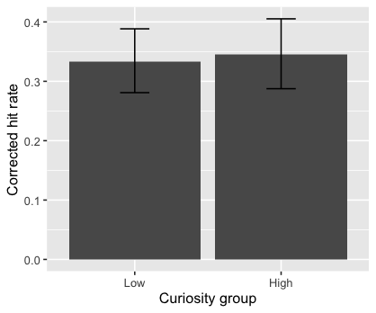

```
Linear mixed-effects model fit by maximum likelihood
 Data: inside.hit.rate.curiosity.group.median
```

|  | AIC | BIC | logLik |
| --- | --- | --- | --- |
|  | -57.11271 | -42.89602 | 34.55635 |

```
Random effects:
 Formula: ~1 + CurGrp | SubjectNo
 Structure: General positive-definite, Log-Cholesky parametrization
            StdDev    Corr
(Intercept) 0.1616591 (Intr)
CurGrpHigh  0.1163067 -0.178
Residual    0.0630181

Fixed effects: SrcAcc ~ CurGrp
```

|  | Value | Std.Error | DF | t-value | p-value |
| --- | --- | --- | --- | --- | --- |
| (Intercept) | 0.3337652 | 0.02778799 | 39 | 12.011135 | 0.0000 |
| CurGrpHigh | 0.0157809 | 0.02374100 | 38 | 0.664711 | 0.5102 |

```
 Correlation:
           (Intr)
CurGrpHigh -0.285

Standardized Within-Group Residuals:
         Min           Q1          Med           Q3          Max
-1.285056920 -0.269988837  0.004146468  0.360052471  0.958419569

Number of Observations: 79
Number of Groups: 40
```

#### 3.4.2.1 Curiosity groups and temporal order of the objects

##### 3.4.2.1.1 Check the data

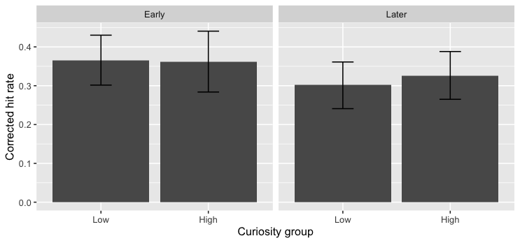

| CurGrpMedian | ObjOrdGrp | Mean | SD | N |
| --- | --- | --- | --- | --- |
| High | Early | 0.3620883 | 0.2508536 | 39 |
| High | Later | 0.3250512 | 0.1940166 | 39 |
| Low | Later | 0.3023416 | 0.1941584 | 40 |
| Low | Early | 0.3651888 | 0.2096820 | 40 |

|  | Model | df | AIC | BIC | logLik | Test | L.Ratio | p-value |
| --- | --- | --- | --- | --- | --- | --- | --- | --- |
| baseline | 1 | 8 | -72.44735 | -47.94659 | 44.22368 |  |  |  |
| ord.model | 2 | 9 | -74.86732 | -47.30396 | 46.43366 | 1 vs 2 | 4.419967 | 0.0355 |
| cur.model | 3 | 10 | -73.21838 | -42.59243 | 46.60919 | 2 vs 3 | 0.351067 | 0.5535 |
| int.model | 4 | 11 | -71.50777 | -37.81923 | 46.75389 | 3 vs 4 | 0.289386 | 0.5906 |

```
Linear mixed-effects model fit by maximum likelihood
 Data: inside.hit.rate.item.order.curiosity.median[!is.na(CurGrpMedian)]
```

|  | AIC | BIC | logLik |
| --- | --- | --- | --- |
|  | -71.50777 | -37.81923 | 46.75389 |

```
Random effects:
 Formula: ~1 + CurGrpMedian + ObjOrdGrp | SubjectNo
 Structure: General positive-definite, Log-Cholesky parametrization
                 StdDev     Corr
(Intercept)      0.16091154 (Intr) CrGrMH
CurGrpMedianHigh 0.04446963  0.315
ObjOrdGrpLater   0.04332369 -0.874  0.114
Residual         0.14315566

Fixed effects: SrcAcc ~ ObjOrdGrp + CurGrpMedian + ObjOrdGrp:CurGrpMedian
```

|  | Value | Std.Error | DF | t-value | p-value |
| --- | --- | --- | --- | --- | --- |
| (Intercept) | 0.3651888 | 0.03449308 | 115 | 10.587308 | 0.0000 |
| ObjOrdGrpLater | -0.0628472 | 0.03315772 | 115 | -1.895402 | 0.0605 |
| CurGrpMedianHigh | 0.0019545 | 0.03351193 | 115 | 0.058322 | 0.9536 |
| ObjOrdGrpLater:CurGrpMedianHigh | 0.0247503 | 0.04615395 | 115 | 0.536256 | 0.5928 |

```
 Correlation:
                                (Intr) ObjOGL CrGrMH
ObjOrdGrpLater                  -0.596
CurGrpMedianHigh                -0.405  0.478
ObjOrdGrpLater:CurGrpMedianHigh  0.330 -0.687 -0.689

Standardized Within-Group Residuals:
        Min          Q1         Med          Q3         Max
-2.02412586 -0.59865810 -0.02153929  0.60919798  2.35754090

Number of Observations: 158
Number of Groups: 40
```